# Toksyczność i kompetytywność w grach komputerowych- raport z badania

Michał Kostewicz

Spis treści jest klikalny, tj. można kliknąć na konkretną sekcję, aby zostać do niej przeniesionym

Badanie zostało przeprowadzone miedzy 19 a 30 marca 2021 za pomocą platformy Qualtrics.

Badanie miało formę jednoczęściowego kwestionariusza, którego wypełnienie zajmowało około 10-12 minut.

Badanie było dystrybuowane na Facebooku na grupach o tematyce okołokomputerowej oraz grupach skupiających się na konkretnych grach.

## Cel badania

Badanie miało na celu znalezienie zmiennych psychologicznych, które mogłyby **wyjaśnić toksyczność w grach komputerowych**.

## Statystyki demograficzne uczestników badania

W link z ankietą kliknęło 1821 osób, z czego 950 osób ją ukończyło (52,2%).

Od tej sumy zostały odjęte osoby niepełnoletnie (n= 108; 5,9%) oraz osoby, które wypełniły ankietę poprzez uzupełnianie odpowiedzi otwartych w sposób niepowiązany z badaniem (n= 6). Z bazy danych usunięte zostały także kolejne dwie osoby, które wypełniały ankietę dłużej o kilkadziesiąt odchyleń standardowych niż reszta ankietowanych (n= 2).

Na następnych wykresach zobaczysz dane demograficzne osób, które wzięły udział w badaniu

### Płeć

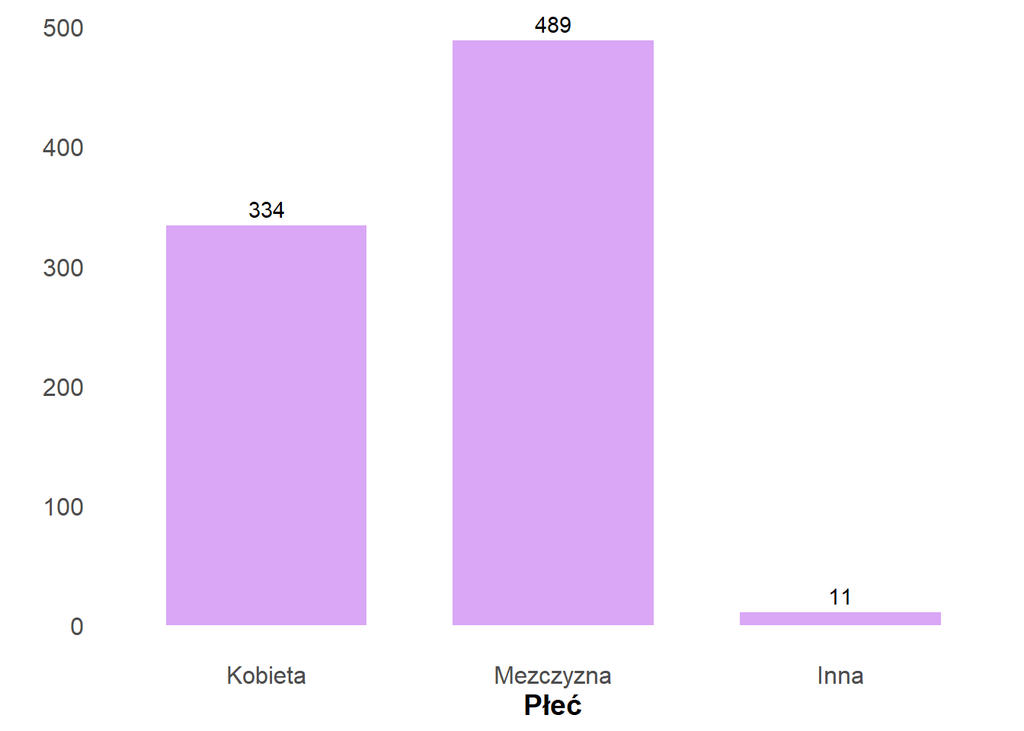

### Miejsce zamieszkania

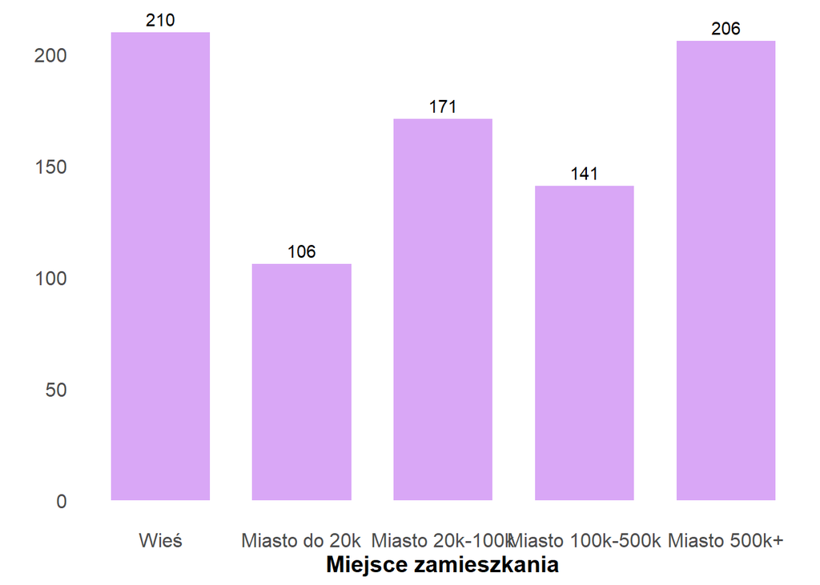

### Wykształcenie

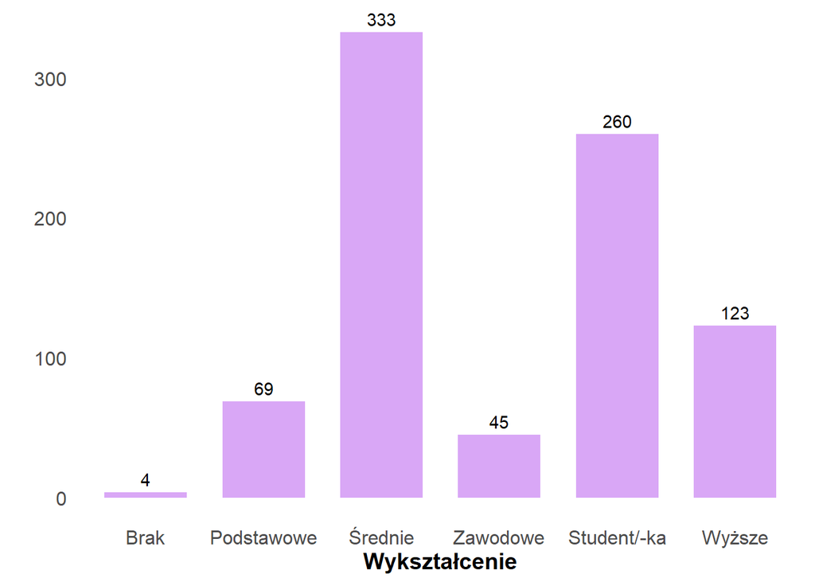

## Dane odnośnie grania

### Od kiedy grają w gry komputerowe?

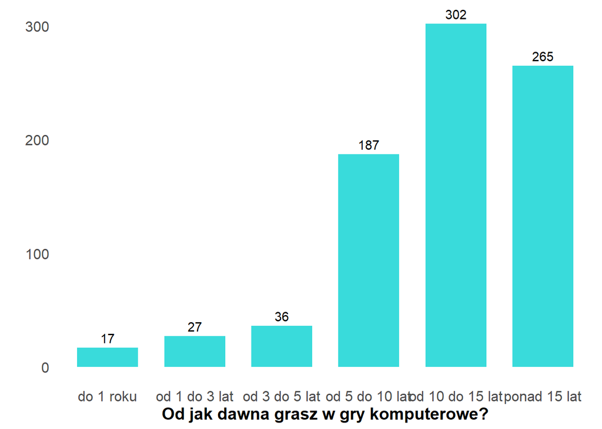

### Ile grają tygodniowo?

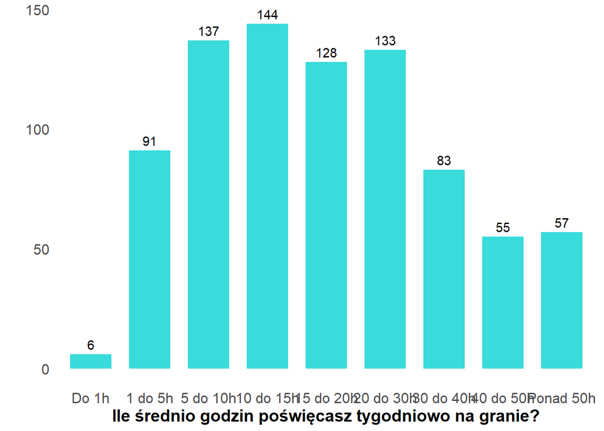

### Z kim grają?

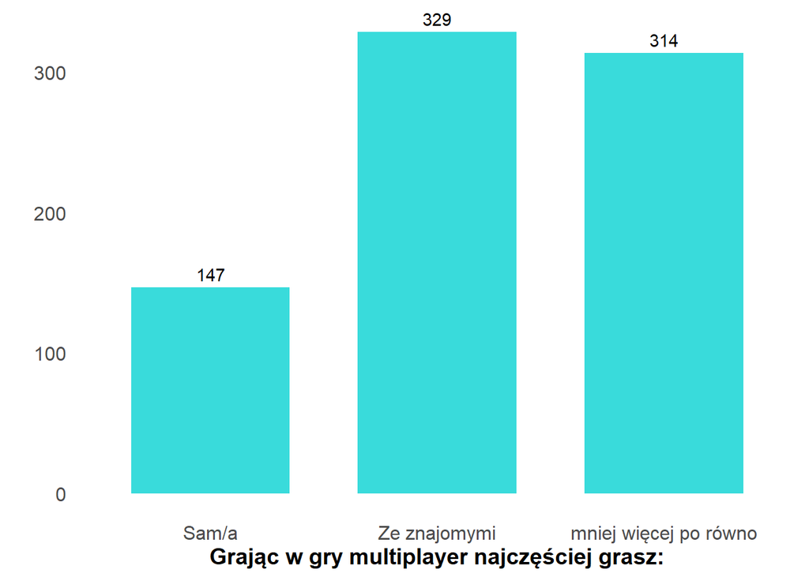

## Jak rozumieć wykresy zmiennych

Na poniższym obrazku widać wykres seksizmu w grach komputerowych w podziale na płeć.

[figure not shown]

Wykres przedstawia średni wynik uzyskany przez kobiety oraz mężczyzn. Na oryginalej skali można było wybierać odpowiedzi od 1 (Zdecydowanie się nie zgadzam) do 7 (Zdecydowanie się zgadzam). Zakres wyników (skala pozioma) jest taki sam.

Czarna kropka pośród pozostałych kropek to średnia uzyskana przez wszystkie osoby z tej samej grupy.

Pozostałe kropki to poszczególne wyniki konkretnych osób.

wykres i pole pod wykresem przedstawia rozkład wartości dla danej zmiennej, tzn. tam, gdzie wykres jest grubszy, tam więcej osób uzyskiwało taki wynik.

prostokąt pod wykresem przedstawia wyniki znajdujące się powyżej 25% aż do 75% wartości w sytuacji, w której uszeregowalibyśmy wyniki od najmniejszego do największego. Innymi słowy, gdyby nasz zbiór danych składał się z liczb od 1 do 100, to owy prostokąt sygnalizowałby liczby od 26 do 75.

Pionowa kreska w prostokącie pokazuje medianę, czyli najczęstszy wynik.

Pozioma kreska rozszerza obszar pokazany przez prostokąt- zaczyna się przy 12.5% wartości, a kończy przy 87.5% wartości.

## Badane zmienne

W tej części opiszę zmienne i pokażę wykresy wartości średnich. Testy statystyczne przedstawione zostaną w sekcji Testy statystyczne.

### Seksizm

Skorzystałem ze skali seksizmu wymyślonej przez Gliska i Fiske (1996). W ich ujęciu seksizm można podzielić na dwa odmienne seksizmy- wrogi oraz życzliwy. Do obydwu seksizmów było po 5 pytań, na ktore można było udzielić odpowiedzi od 1 (zdecydowanie się nie zgadzam) do 7 (zdecydowanie się zgadzam)

#### Seksizm życzliwy

Seksizm życzliwy zakłada, że kobiety zasługują na specjalne traktowanie i należy je czcić i zasługją na specjalne traktowanie za sam fakt bycia kobietą tak długo, jak kobieta nie wychodzi ze swojej roli.

##### Użyte pozycje

Zakres: 1 (Zdecydowanie się nie zgadzam) - 7 (Zdecydowanie się zgadzam)

1. Ludzie nie są naprawdę szczęśliwi, jeśli nie są w związku uczuciowym z osobą przeciwnej płci.
2. Bez względu na swoje osiągnięcia zawodowe, mężczyzna nie jest całością bez miłości kobiety.
3. Każdy mężczyzna powinien mieć partnerkę, którą adoruje.
4. W porównaniu do mężczyzn kobiety mają bardziej wyrafinowany gust i poczucie dobrego smaku.
5. Kobiety powinny być wielbione i chronione przez mężczyzn.

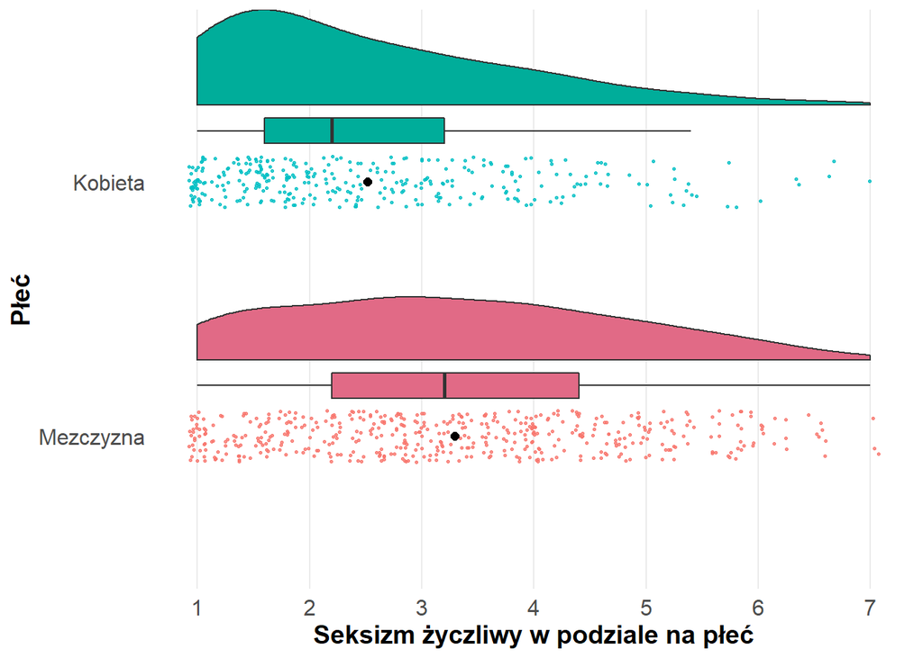

#### Seksizm wrogi

Seksizm wrogi zakłada bezpośrednie, otwarte uprzedzenie względem kobiet.

##### Użyte pozycje

Zakres: 1 (Zdecydowanie się nie zgadzam) - 7 (Zdecydowanie się zgadzam)

1. Z chwilą, gdy kobieta zdobędzie mężczyznę, zazwyczaj próbuje trzymać go „krótko”.
2. Kiedy kobiety przegrywają z mężczyznami w uczciwej rywalizacji, zwykle narzekają, że są dyskryminowane.
3. Kobiety wyolbrzymiają problemy, które mają w pracy.
4. Kobiety zbyt łatwo się obrażają.
5. Przejmując kontrolę nad mężczyznami, kobiety dążą do zdobycia władzy.

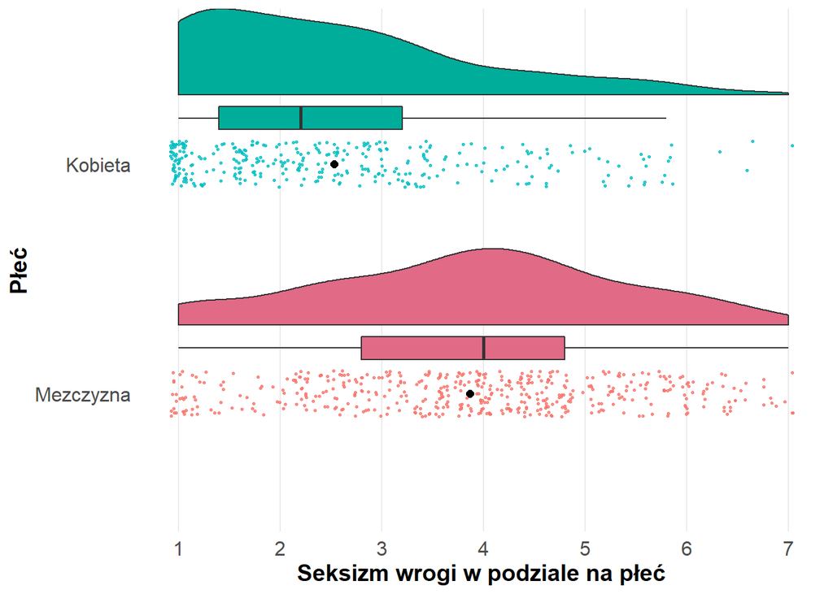

#### Seksizm w grach

Skala ta została skonstruowana na podstawie kwestionariusza oraz konsultacji z graczami i badaczami zajmującymi się tą tematyką (Fox i Tang, 2014). W efekcie uzyskano 16-itemową skalę, którą przetłumaczyłem osobiście, po czym naniosłem poprawki, które wyniknęły ze zwrotnego tłumaczenia wykonanego przez osobę biegłą w języku angielskim. Skala miała mierzyć postrzeganie kobiet w sposób seksistowski w świecie gier komputerowych.

##### Użyte pozycje

Zakres: 1 (Zdecydowanie się nie zgadzam) - 7 (Zdecydowanie się zgadzam)

1. Większość kobiet gra na komputerze tylko dlatego, że gra ze swoim chłopakiem.
2. Większość kobiet grających na komputerze nie jest w tych grach zbyt dobra.
3. Kobiety grają na komputerze, by być lepiej postrzegane przez mężczyzn.
4. Kobiety grają na komputerze, by zdobyć uwagę mężczyzn.
5. Kobiety za często dają się urazić tym, co dzieje się w grach komputerowych.
6. Kobiety za często dają się urazić seksistowskimi komentarzami w grach
7. Kobiety są przewrażliwione na punkcie seksistowskich żartów i zdjęć nagich kobiet, na które można się natknąć grając.
8. Kobiety nazywające siebie “kobietą-graczem” (ang. gamer girl) uważają, że należy im się specjalne traktowanie.
9. Fakt, że kobiety grają, sprawia, że poziom gry się obniża.
10. Jeśli jest jakaś kobieta w gildii lub drużynie, to jest ona na ogół jej najsłabszym członkiem.
11. Kobiety nie radzą sobie z trash-talkiem równie dobrze, co mężczyźni.
12. Granie z kobietami sprawia, że gra staje się mniej przyjemna.
13. Świat gier komputerowych to świat dla mężczyzn, do którego kobiety nie należą.
14. Kobietom w grach komputerowych bardziej zależy na nawiązywaniu kontaktów z innymi graczami niż czymkolwiek innym.
15. Kobiety wolą spędzić czas na przebieraniu swojej postaci w grze niż na graniu.
16. Kobiety nie grają na komputerze po to, by kogoś zabić lub coś osiągnąć.

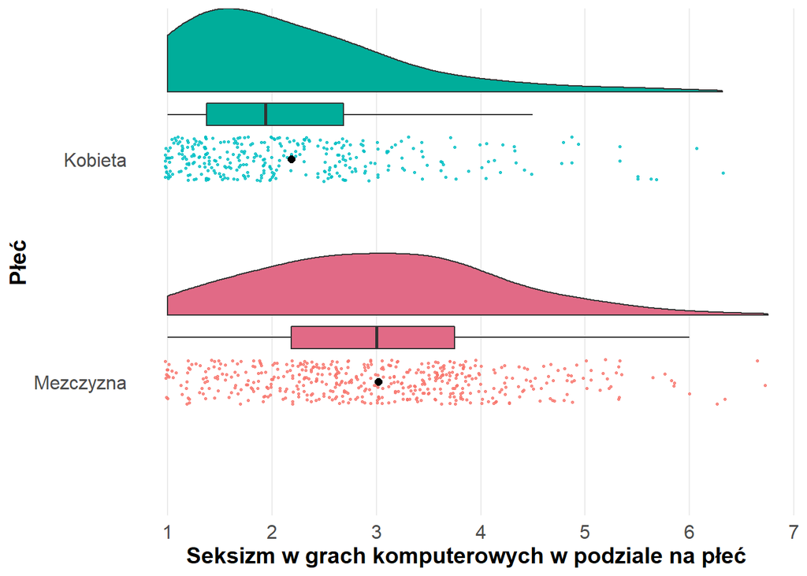

### Skale postaw

#### Orientacja na dominację społeczną

Orientacja na dominację społeczną (SDO) jest konstruktem stworzonym przez Pratto, Sidaniusa, Stallworth i Malle (1994), który cechuje się preferencją jednostki do utrzymywania nierówności między grupami. Teoria ta zakłada, że istniejące w społeczeństwie nierówność oraz hierarchiczność grup są uzasadnione i nie ma powodu, aby próbować wyrównywać pozycje różnych grup.

##### Użyte pozycje

Zakres: 1 (Zdecydowanie się nie zgadzam) - 7 (Zdecydowanie się zgadzam)

1. Prawdopodobnie to dobrze, że pewne grupy są na szczycie, a inne na dole.
2. Mniej ważne grupy powinny znać swoje miejsce.
3. Powinniśmy zrobić wszystko, co w naszej mocy, żeby wyrównywać szanse różnych grup.(pozycja odwrócona)
4. Powinniśmy zwiększać równość społeczną. (pozycja odwrócona)
5. Grupy lepsze powinny dominować nad grupami gorszymi.

[figure not shown]

#### Prawicowy autorytaryzm

Prawicowy autorytaryzm (RWA) Altemeyera (1998) jest konstruktem mierzącym autorytarne i konserwatywne wartości. Osoby o wysokich wynikach na skali prawicowego autorytaryzmu cechują się uległością autorytetom, wiarą w tradycyjne wartości i potępianie osób, które nie podporządkowują się wspomnianym wartościom.

##### Użyte pozycje

Zakres: 1 (Zdecydowanie się nie zgadzam) - 7 (Zdecydowanie się zgadzam)

1. To, czego naprawdę potrzebuje nasz kraj zamiast zwiększania zakresu praw i swobód obywatelskich, to solidna dawka prawdziwego prawa i porządku.
2. Odwracanie się od tradycji okaże się pewnego dnia fatalne w skutkach.
3. Posłuszeństwo i szacunek dla autorytetów to najważniejsze wartości, jakich powinny nauczyć się dzieci.
4. To, czego naprawdę potrzebuje nasz kraj, to silny i zdecydowany przywódca, który pokona zło i wskaże nam właściwą drogę.
5. Przyzwoitość i posłuszeństwo wobec prawa są dla nas na dłuższą metę lepsze, niż ciągłe podważanie zasad, na których oparta jest nasza społeczność.
6. Właściwym kluczem do dobrego życia jest dyscyplina i posłuszeństwo.

[figure not shown]

### Toksyczność

Toksyczność w grach była mierzona za pomocą skali autorstwa Tanga i Foxa (2016). Skala ta była podzielona na dwie podskale. Jedna z nich dotyczyła toksyczności związanej z płcią, druga toksyczności ogólnej. Każda z podskal była złożona z pięciu itemów, co do których badani mieli na pięciostopniowej skali określić, jak często zdarzały im się wymienione zachowania (1= Nigdy, 5= Zawsze). Skala została przetłumaczona przeze mnie na język polski z zachowaniem niektórych elementów w języku angielskim.

#### Toksyczność związana z płcią

Toksyczność związana z płcią jest związana z bezpośrednią toksycznością przejawianą w grach, która może być określona jako molestowanie (sexual harassment).

##### Użyte pozycje

Zakres: 1 (Nigdy) - 5 (Zawsze)

1. Sugerowałem/-am, że ktoś gra z powodów związanych ze swoją płcią (np. chce się przypodobać swojemu partnerowi, szuka atencji).
2. Mówiłem/-am komuś, że ją/go kocham (lub pytałem/-am, czy chce ze mną być).
3. Mówiłem/-am seksistowskie żarty lub/i używałem/-am seksistowskich obelg (np. “wracaj do kuchni”).
4. Komentowałem/-am czyjąś wagę lub wygląd (np. “grubasie”, “brzydalu”, “fat”, “ugly”)
5. Żartowałem/-am o gwałcie lub mówiłem/-am komuś, że go zgwałcę.

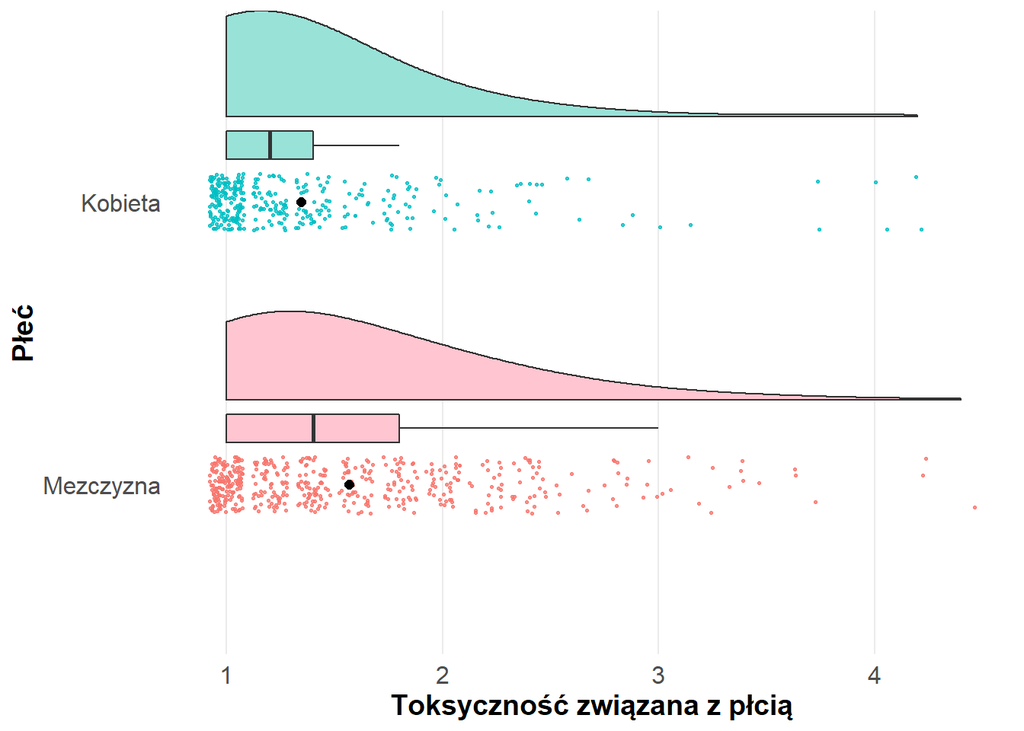

#### Toksyczność ogólna

Toksyczność ogólna jest rozumiana również jako bezpośrednia forma toksyczności, jednak dotyczy ona zachowań toksycznych nieukierunkowanych na płeć lub wygląd odbiorcy negatywnych komunikatów.

##### Użyte pozycje

1. Przeklinałem/-am (np. “kurwa”, “chuj”, “fuck”, “bitch”, “shit”).
2. Obrażałem/-am innych (np. nazywanie trollem, loserem, feederem, mówienie “zamknij się”, wyzywanie).
3. Komentowałem/-am czyjąś inteligencję (np. “debil”, “idiota”, “retard”, “down”).
4. Komentowałem/-am czyjeś umiejętności (np. “noob”, “camper”, “feeder”) lubkomentowałem/-am to, jak ktoś sobie radzi (np. zarzucanie komuś, że przez niego się przegrało).
5. Prosiłem/-am kogoś, aby wyszedł z gry, przestał w nią grać lub ją odinstalował.

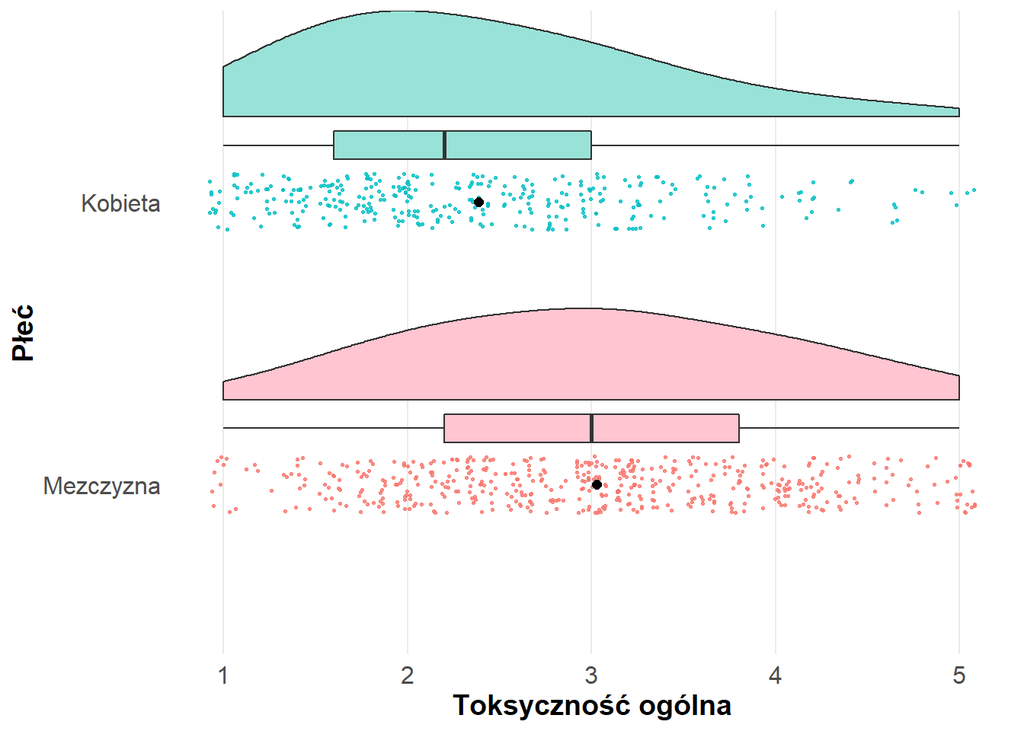

## Testy statystyczne

### Testy t-studenta

Test t-studenta służy do porówywania ze sobą wyników uzyskanych przez dokładnie dwie grupy. Za jego pomocą można sprawdzić, czy grupy istotnie statystycznie różnią się między sobą.

Poniżej znajduje się tabela, w której przedstawione są wyniki uzyskane na wszystkich mierzonych skalach w podziale na płeć. M oznacza średnią, SD odchylenie standardowe, t- wartość testu t studenta wraz z poziomiem istotności (gwiazdki) oraz d i 95%CI, czyli mierniki siły efektu

Siła efektu

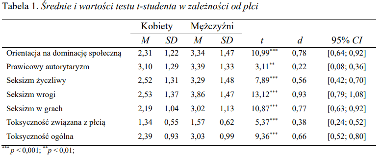